# F4RM — Section 4: Comparisons and Pareto Frontier

> **Notebook 3 of 3**: Cross-system comparison of F4RM-WiSARD and F4RMS against tabular ML baselines (DT, RF, CatBoost, XGBoost, LightGBM, MLP, FT-Transformer, TabPFN) and prior weightless systems (BTHOWeN, DWN, ULEEN), unified on a Pareto (memory, accuracy) frontier across the 21-dataset benchmark suite.

> **Companion notebooks**:
> - `F4RM_01_Foundations_and_Headline.ipynb` — concept + E1–E5 headline
> - `F4RM_02_Robustness_Ablations.ipynb` — E6–E11 robustness sweeps

## Organization

- **4.1** — Pareto schema and cache layout
- **4.2** — Per-system summaries
  - 4.2.1 F4RM-WiSARD and F4RMS
  - 4.2.2 Random-WiSARD baseline
  - 4.2.3 Tabular ML baselines (DT/RF/CatBoost/XGBoost/LightGBM/MLP/FT-Transformer/TabPFN)
  - 4.2.4 Prior weightless: BTHOWeN
  - 4.2.5 Prior weightless: DWN
  - 4.2.6 Prior weightless: ULEEN
- **4.3** — Pareto frontier extraction
- **4.4** — Iso-accuracy / iso-memory comparisons
- **4.5** — Paper-drift verification (BTHOWeN Table III, DWN Table 5)
- **4.6** — Documented caveats and port limitations

```python
# === Imports ===
import os, sys, pickle, warnings
from pathlib import Path
import numpy as np
import pandas as pd
import matplotlib.pyplot as plt
from IPython.display import Image, display, Markdown

warnings.filterwarnings("ignore")

REPO = Path("/Users/muanlartins/repos/masters")
DELIV = REPO / "notebooks" / "f4rm"
CACHE_DIR = DELIV / "cache"
TBL_DIR = DELIV / "paper_tables"
FIG_DIR = DELIV / "paper_figures"
PRIOR_DIR = REPO / "wisardpkg" / "scripts"
```

## 4.1 — Pareto schema and cache layout

Every experimental cell across all 16 systems is stored as one row in `section4_pareto_points.pkl` (the main cache) or in a sibling cache `section4_*.pkl` that gets auto-merged when the Pareto frontier is built.

**Schema** (one row per `(system, dataset, hp_id, seed)`):

| Column | Description |
| --- | --- |
| `system` | One of: F4RM-WiSARD-{dense,cuckoo}, Random-WiSARD-{dense,cuckoo}, F4RMS, BTHOWeN, DWN, ULEEN, DT, RF, CatBoost, XGBoost, LightGBM, MLP, FT-Transformer, TabPFN |
| `dataset` | Benchmark dataset name |
| `hp_id` | JSON-serialised hyperparameter dict (used as a unique key per cell) |
| `seed` | Random seed for the train/test split + per-system RNG |
| `test_acc` | Test-set accuracy (held-out 20%) |
| `mem_bytes` | Deployed-model memory footprint, accounted per system's convention |
| `mem_method` | String identifier of the memory accounting (e.g., `"wisard_dense_hashmap"`, `"bthowen_analytical_bloom_post_binarize"`, `"uleen_binarized_table"`) |
| `train_s`, `infer_us_per_sample` | Wall-clock perf |
| `infeasible`, `infeasible_reason`, `note` | Status + provenance |

```python
# === Load the merged Pareto cache ===
SECTION4_DF = pd.read_csv(TBL_DIR / "section4_all_points.csv")
print(f"Total rows in merged Pareto cache: {len(SECTION4_DF):,}")
print()
print("Per-system row counts:")
print(SECTION4_DF.groupby("system").size().sort_values(ascending=False).to_string())
```

```
Total rows in merged Pareto cache: 229,980

Per-system row counts:
system
DT                      34300
F4RM-WiSARD-cuckoo      34160
F4RM-WiSARD-dense       34160
Random-WiSARD-cuckoo    34160
Random-WiSARD-dense     34160
BTHOWeN                 15156
F4RMS                   14031
XGBoost                  8250
LightGBM                 7035
RF                       5875
MLP                      5040
ULEEN                    1674
CatBoost                  812
DWN                       741
FT-Transformer            321
TabPFN                    105
```

## 4.2 — Per-system summaries

### 4.2.1 F4RM-WiSARD and F4RMS

**F4RM-WiSARD** is migrated from E11's per-cell results: each (a, t, bleach) hyperparameter cell becomes a Pareto point. Two memory accountings (dense hashmap and Cuckoo filter) generate two systems: `F4RM-WiSARD-dense` and `F4RM-WiSARD-cuckoo`.

**F4RMS** is the K-ensemble of F4RM. Sweep grid: a∈{4,8,16,32}, t∈{4,8,16,32,64}, bleach∈{1,2}, K∈{5,10,25,50,100}.

The headline F4RMS Section 4 sweep covered 15/21 datasets due to budget; an extension run filled the missing 6 large datasets (EEG Eye State, Letter Recognition, Magic Gamma, Pendigits, SatImage, Waveform) with a reduced grid (a∈{8,16,32}, t∈{16,64}, K∈{10,50}).

**Final coverage**: 21/21 datasets, 14,031 rows (13,815 main + 216 extension).

```python
# === F4RMS coverage ===
sub = SECTION4_DF[SECTION4_DF.system.isin(['F4RM-WiSARD-dense', 'F4RM-WiSARD-cuckoo', 'F4RMS', 'Random-WiSARD-dense', 'Random-WiSARD-cuckoo'])]
print(sub.groupby('system').agg(rows=('seed','count'), datasets=('dataset','nunique')).to_string())
```

```
                       rows  datasets
system
F4RM-WiSARD-cuckoo    34160        21
F4RM-WiSARD-dense     34160        21
F4RMS                 14031        21
Random-WiSARD-cuckoo  34160        21
Random-WiSARD-dense   34160        21
```

### 4.2.3 Tabular ML baselines

Eight tabular ML methods, each with their own per-system grid:

| System | Wrapper | Notes |
| --- | --- | --- |
| **DT** | sklearn DecisionTreeClassifier | grid over criterion, max_depth, min_samples_split |
| **RF** | sklearn RandomForestClassifier | n_estimators, max_depth, min_samples_split |
| **CatBoost** | `catboost.CatBoostClassifier` | iterations, depth, learning_rate, l2_leaf_reg |
| **XGBoost** | `xgboost.XGBClassifier` | n_estimators, max_depth, learning_rate, reg_lambda |
| **LightGBM** | `lightgbm.LGBMClassifier` | n_estimators, num_leaves, learning_rate, reg_lambda |
| **MLP** | sklearn MLPClassifier | hidden_layer_sizes, learning_rate_init, max_iter, alpha |
| **FT-Transformer** | `rtdl_revisiting_models.FTTransformer` | d_token, n_blocks, attention heads/dropout, lr |
| **TabPFN** | `tabpfn.TabPFNClassifier` | requires `TABPFN_TOKEN` env var (license-gated) |

**Memory accounting**: tree-based models use the on-disk save_model file size (reflects the deployed serialized model). MLP / FT-Transformer use parameter count × 4 bytes (f32). TabPFN is a "no parameters" pretrained model, so memory accounting is the loaded model file size.

```python
# === Tabular baselines coverage ===
baselines = ['DT','RF','CatBoost','XGBoost','LightGBM','MLP','FT-Transformer','TabPFN']
sub = SECTION4_DF[SECTION4_DF.system.isin(baselines)]
print(sub.groupby('system').agg(rows=('seed','count'), datasets=('dataset','nunique')).to_string())
print()
inf = sub[sub.get('infeasible', False) == True]
if len(inf):
    print(f"\nInfeasible rows ({len(inf):,}):")
    print(inf.groupby('system').size().to_string())
```

```
                 rows  datasets
system
CatBoost          812        21
DT              34300        20
FT-Transformer    321        21
LightGBM         7035        14
MLP              5040        18
RF               5875        17
TabPFN            105        21
XGBoost          8250        16


Infeasible rows (105):
system
TabPFN    105
```

**TabPFN**: 100% infeasible because it requires accepting a license at https://ux.priorlabs.ai and providing `TABPFN_TOKEN` env var. Not chased in this work; documented in caveats.

### 4.2.4 BTHOWeN — Susskind et al., PACT 2022

**Reference**: arXiv:2203.01479 ([github](https://github.com/ZSusskind/BTHOWeN)). Lives at `wisardpkg/wisardpkg/models/bthowen.py` as a clean port using our wisardpkg's BloomWisard with H3 universal hashing.

**Architecture additions** (in wisardpkg C++):

- H3 universal hash mode (`hashMode="h3"`) matching paper §III-A-2
- Native `GaussianThermometer` (paper §II-E)
- `getRawVotes()` for bleach binary search

**Memory accounting** (`mem_method="bthowen_analytical_bloom_post_binarize"`) matches paper's `calc_model_size.py`: post-binarisation, one bit per Bloom slot.

**Sweep grids run**:

```python
# === BTHOWeN coverage ===
sub = SECTION4_DF[SECTION4_DF.system == 'BTHOWeN']
print(f"BTHOWeN: {len(sub):,} rows / {sub.dataset.nunique()} datasets / {sub.hp_id.nunique()} unique cells")
```

```
BTHOWeN: 15,156 rows / 31 datasets / 118 unique cells
```

### 4.2.5 DWN — Differentiable Weightless Neural Networks (ICML 2024)

**Reference**: arXiv:2410.11112 ([github](https://github.com/alanbacellar/DWN)). Lives at `wisardpkg/wisardpkg/models/dwn.py` as a CPU-only PyTorch port.

**Verified bit-exact** vs reference CUDA kernels for both EFD forward and backward (`wisardpkg/test/test_dwn.py`).

**Sweep grids**:

- Compact 6-cell grid: bpi∈{2,3,6}, n=4 or 6, layers (l1, l2) ∈ {(200,100), (500,250), (1000,500), (2000,1000)}, epochs 10–20
- Long-epoch retry on phoneme + higgs-small: epochs=50, batch=64
- **Paper-fidelity configs** (Table 17) on phoneme + australian: bpi=200, layer_sizes=[21000,21000,21000] for phoneme, [12000]×3 for australian, multi-stage LR `1e-2(30)→1e-3(30)→1e-4(15)`

**Audit additions** (per the parallel-session audit at `/tmp/prior_wisard_audit_handoff.md`):

- `num_luts_l3` parameter for 3-layer model (paper §4.4 uses 3-5 layers)
- `layer_sizes` list parameter for arbitrary N-layer
- `lr_schedule` for paper's multi-stage LR
- `spectral_lambda` for spectral regularization (paper §3.4)
- `tau` parameter exposed (paper Table 17 uses `1/0.001` for skin-seg/higgs)

```python
# === DWN coverage ===
sub = SECTION4_DF[SECTION4_DF.system == 'DWN']
print(f"DWN: {len(sub):,} rows / {sub.dataset.nunique()} datasets / {sub.hp_id.nunique()} unique cells")
```

```
DWN: 741 rows / 31 datasets / 14 unique cells
```

### 4.2.6 ULEEN — Susskind et al., ACM TACO 2023

**Reference**: doi:10.1145/3629522 ([github](https://github.com/ZSusskind/ULEEN)). Lives at `wisardpkg/wisardpkg/models/uleen.py` as a CPU-only PyTorch port.

**Verified bit-exact** vs reference C++ H3 hash (`wisardpkg/test/test_uleen.py`).

**Architecture options exposed (post-audit)**:

- `thermometer="gaussian"` — paper default, +0.6pp expected on MNIST per paper Fig. 11; our smoke saw +6pp on Iris
- `pruning_ratio` — post-train RAM pruning + fine-tune, paper §3.1.3. Our smoke matched paper claim of ~27% size reduction with ≤1% acc loss
- `dropout_p=0.5` — paper's regularization (we see it doesn't transfer to small tabular data; our final sweep keeps `dropout_p=0` per smoke)
- `lr=1e-3, epochs=80` — paper's training schedule

**Memory accounting** (`mem_method="uleen_binarized_table"`) is paper-style: table-only, excluding H3 + input_order metadata. Pass `include_metadata=True` for the deploy-time footprint.

**Sweep grids**:

- Original 6-cell grid (lr=1e-2, 30-50 ep, linear thermometer): 558 rows
- Paper-LR retry (lr=1e-3, 80 ep, linear thermometer): 558 rows
- Final tuned (gaussian + pruning(0.27) + paper LR): 558 rows

**Total**: 1,674 rows / 31 datasets.

**Note**: ULEEN paper's tabular benchmarks (MNIST + MLPerf Tiny audio/vision) do not overlap with our tabular suite. There is no per-dataset reproduction comparison for ULEEN; our numbers stand on their own.

```python
# === ULEEN coverage ===
sub = SECTION4_DF[SECTION4_DF.system == 'ULEEN']
print(f"ULEEN: {len(sub):,} rows / {sub.dataset.nunique()} datasets / {sub.hp_id.nunique()} unique cells")
```

```
ULEEN: 1,674 rows / 31 datasets / 18 unique cells
```

## 4.3 — Pareto frontier extraction

Per-(system, dataset) Pareto frontier from the merged points: a frontier point is one that is not dominated by any other (system, dataset) point on the (memory, accuracy) plane.

After filtering infeasible rows and aggregating by `hp_id` (mean across seeds), the per-dataset frontier is the upper envelope of (mean_acc) vs (mean_memory).

**Total**: 3,421 frontier points across 346 (system, dataset) pairs.

```python
# === Frontier coverage ===
fp = pd.read_csv(TBL_DIR / "section4_frontiers.csv")
print(f"Total frontier points: {len(fp):,} | (system, dataset) pairs: {len(set(zip(fp.system, fp.dataset)))}")
print()
print("Per-system frontier coverage:")
cov = fp.groupby('system').agg(datasets=('dataset','nunique'), points=('test_acc','count'))
cov = cov.sort_values('datasets', ascending=False)
print(cov.to_string())
```

```
Total frontier points: 3,421 | (system, dataset) pairs: 346

Per-system frontier coverage:
                      datasets  points
system
BTHOWeN                     31     191
DWN                         31      80
ULEEN                       31     155
CatBoost                    21      46
F4RM-WiSARD-cuckoo          21     334
F4RM-WiSARD-dense           21     334
F4RMS                       21     153
FT-Transformer              21      56
Random-WiSARD-cuckoo        21     332
Random-WiSARD-dense         21     332
TabPFN                      21       0
DT                          20     855
MLP                         18     248
RF                          17     119
XGBoost                     16      57
LightGBM                    14     108
```

### Per-dataset Pareto grid

[figure not shown]

```python
# === 21-panel Pareto grid ===
display(Image(str(FIG_DIR / "section4_pareto_grid.png"), width=1200))
```

## 4.4 — Iso-accuracy / iso-memory comparisons

For each (F4RM_system, baseline) pair on each dataset, two summary scores:

- **iso_acc_wins**: at each accuracy level on the F4RM frontier, which side uses less memory? Wins per system are summed across accuracy levels.
- **iso_mem_wins**: at each memory level on the F4RM frontier, which side has higher accuracy? Wins per system are summed across memory levels.

The per-pair table holds 570 rows; the `section4_aggregated_wins` summary aggregates across datasets.

```python
# === Iso comparisons (head only — full table is 570 rows) ===
df = pd.read_csv(TBL_DIR / "section4_iso_comparisons.csv")
print(f"Total iso-comparison pairs: {len(df):,}")
display(df.head(15).style.set_caption("section4_iso_comparisons.csv (first 15 rows)"))
```

```
Total iso-comparison pairs: 570
```

section4_iso_comparisons.csv (first 15 rows)

|  | dataset | system_a | system_b | iso_acc_levels_compared | iso_acc_wins_a | iso_acc_wins_b | iso_mem_levels_compared | iso_mem_wins_a | iso_mem_wins_b | feasible_acc_overlap_lo | feasible_acc_overlap_hi | feasible_mem_overlap_lo | feasible_mem_overlap_hi |
| --- | --- | --- | --- | --- | --- | --- | --- | --- | --- | --- | --- | --- | --- |
| 0 | Balance Scale | F4RM-WiSARD-dense | Random-WiSARD-dense | 101 | 40 | 45 | 50 | 25 | 18 | 0.230400 | 0.900800 | 237.000000 | 17512.000000 |
| 1 | Balance Scale | F4RM-WiSARD-dense | Random-WiSARD-cuckoo | 101 | 0 | 101 | 50 | 0 | 50 | 0.230400 | 0.900800 | 237.000000 | 3686.400000 |
| 2 | Balance Scale | F4RM-WiSARD-dense | DT | 101 | 101 | 0 | 49 | 49 | 0 | 0.456000 | 0.779200 | 1250.000000 | 3791.400000 |
| 3 | Balance Scale | F4RM-WiSARD-dense | RF | 101 | 101 | 0 | 0 | 0 | 0 | 0.827200 | 0.865600 | 58700.600000 | 21644.000000 |
| 4 | Balance Scale | F4RM-WiSARD-dense | CatBoost | 0 | 0 | 0 | 0 | 0 | 0 | 0.917333 | 0.902400 | 64560.000000 | 21644.000000 |
| 5 | Balance Scale | F4RM-WiSARD-dense | XGBoost | 101 | 101 | 0 | 0 | 0 | 0 | 0.884800 | 0.902400 | 490686.600000 | 21644.000000 |
| 6 | Balance Scale | F4RM-WiSARD-dense | LightGBM | 101 | 101 | 0 | 0 | 0 | 0 | 0.900800 | 0.902400 | 304656.200000 | 21644.000000 |
| 7 | Balance Scale | F4RM-WiSARD-dense | MLP | 101 | 99 | 2 | 50 | 42 | 8 | 0.771200 | 0.902400 | 1036.000000 | 21644.000000 |
| 8 | Balance Scale | F4RM-WiSARD-dense | FT-Transformer | 101 | 101 | 0 | 0 | 0 | 0 | 0.850667 | 0.902400 | 69548.000000 | 21644.000000 |
| 9 | Balance Scale | F4RM-WiSARD-dense | TabPFN | 0 | 0 | 0 | 0 | 0 | 0 | 0.230400 | 0.902400 | 237.000000 | 0.000000 |
| 10 | Balance Scale | F4RM-WiSARD-cuckoo | Random-WiSARD-dense | 101 | 101 | 0 | 50 | 50 | 0 | 0.230400 | 0.900800 | 233.000000 | 4556.200000 |
| 11 | Balance Scale | F4RM-WiSARD-cuckoo | Random-WiSARD-cuckoo | 101 | 40 | 45 | 50 | 13 | 28 | 0.230400 | 0.900800 | 49.400000 | 3686.400000 |
| 12 | Balance Scale | F4RM-WiSARD-cuckoo | DT | 101 | 101 | 0 | 49 | 49 | 0 | 0.456000 | 0.779200 | 1250.000000 | 3791.400000 |
| 13 | Balance Scale | F4RM-WiSARD-cuckoo | RF | 101 | 101 | 0 | 0 | 0 | 0 | 0.827200 | 0.865600 | 58700.600000 | 4556.200000 |
| 14 | Balance Scale | F4RM-WiSARD-cuckoo | CatBoost | 0 | 0 | 0 | 0 | 0 | 0 | 0.917333 | 0.902400 | 64560.000000 | 4556.200000 |

```python
# === Aggregated wins ===
df = pd.read_csv(TBL_DIR / "section4_aggregated_wins.csv")
display(df.style.set_caption("section4_aggregated_wins.csv — per-(F4RM_system, baseline) aggregated win rates"))
```

section4_aggregated_wins.csv — per-(F4RM_system, baseline) aggregated win rates

|  | system_a | system_b | n_datasets | iso_acc_wins_a_total | iso_acc_wins_b_total | iso_acc_levels_total | iso_mem_wins_a_total | iso_mem_wins_b_total | iso_mem_levels_total | iso_acc_win_rate_a | iso_mem_win_rate_a |
| --- | --- | --- | --- | --- | --- | --- | --- | --- | --- | --- | --- |
| 0 | F4RM-WiSARD-cuckoo | CatBoost | 21 | 998 | 113 | 1111 | 193 | 103 | 296 | 0.898290 | 0.652027 |
| 1 | F4RM-WiSARD-cuckoo | DT | 20 | 1645 | 375 | 2020 | 631 | 211 | 845 | 0.814356 | 0.746746 |
| 2 | F4RM-WiSARD-cuckoo | FT-Transformer | 21 | 1726 | 92 | 1818 | 305 | 41 | 346 | 0.949395 | 0.881503 |
| 3 | F4RM-WiSARD-cuckoo | LightGBM | 14 | 1010 | 0 | 1010 | 0 | 0 | 0 | 1.000000 | 0.000000 |
| 4 | F4RM-WiSARD-cuckoo | MLP | 18 | 1472 | 144 | 1616 | 659 | 135 | 794 | 0.910891 | 0.829975 |
| 5 | F4RM-WiSARD-cuckoo | RF | 17 | 1414 | 0 | 1414 | 197 | 0 | 197 | 1.000000 | 1.000000 |
| 6 | F4RM-WiSARD-cuckoo | Random-WiSARD-cuckoo | 21 | 648 | 1422 | 2121 | 476 | 320 | 850 | 0.305516 | 0.560000 |
| 7 | F4RM-WiSARD-cuckoo | Random-WiSARD-dense | 21 | 2083 | 38 | 2121 | 898 | 2 | 900 | 0.982084 | 0.997778 |
| 8 | F4RM-WiSARD-cuckoo | TabPFN | 21 | 0 | 0 | 0 | 0 | 0 | 0 | 0.000000 | 0.000000 |
| 9 | F4RM-WiSARD-cuckoo | XGBoost | 16 | 1010 | 0 | 1010 | 49 | 50 | 99 | 1.000000 | 0.494949 |
| 10 | F4RM-WiSARD-dense | CatBoost | 21 | 808 | 303 | 1111 | 132 | 164 | 296 | 0.727273 | 0.445946 |
| 11 | F4RM-WiSARD-dense | DT | 20 | 865 | 1155 | 2020 | 477 | 509 | 994 | 0.428218 | 0.479879 |
| 12 | F4RM-WiSARD-dense | FT-Transformer | 21 | 1612 | 206 | 1818 | 442 | 101 | 543 | 0.886689 | 0.813996 |
| 13 | F4RM-WiSARD-dense | LightGBM | 14 | 995 | 15 | 1010 | 89 | 1 | 99 | 0.985149 | 0.898990 |
| 14 | F4RM-WiSARD-dense | MLP | 18 | 1360 | 256 | 1616 | 713 | 180 | 893 | 0.841584 | 0.798432 |
| 15 | F4RM-WiSARD-dense | RF | 17 | 1330 | 84 | 1414 | 262 | 85 | 347 | 0.940594 | 0.755043 |
| 16 | F4RM-WiSARD-dense | Random-WiSARD-cuckoo | 21 | 7 | 2114 | 2121 | 9 | 876 | 897 | 0.003300 | 0.010033 |
| 17 | F4RM-WiSARD-dense | Random-WiSARD-dense | 21 | 648 | 1422 | 2121 | 591 | 356 | 998 | 0.305516 | 0.592184 |
| 18 | F4RM-WiSARD-dense | TabPFN | 21 | 0 | 0 | 0 | 0 | 0 | 0 | 0.000000 | 0.000000 |
| 19 | F4RM-WiSARD-dense | XGBoost | 16 | 908 | 102 | 1010 | 43 | 105 | 148 | 0.899010 | 0.290541 |
| 20 | F4RMS | CatBoost | 21 | 575 | 536 | 1111 | 79 | 367 | 446 | 0.517552 | 0.177130 |
| 21 | F4RMS | DT | 20 | 33 | 1482 | 1515 | 37 | 153 | 198 | 0.021782 | 0.186869 |
| 22 | F4RMS | FT-Transformer | 21 | 1003 | 310 | 1313 | 543 | 51 | 594 | 0.763899 | 0.914141 |
| 23 | F4RMS | LightGBM | 14 | 984 | 127 | 1111 | 151 | 140 | 296 | 0.885689 | 0.510135 |
| 24 | F4RMS | MLP | 18 | 869 | 343 | 1212 | 661 | 182 | 843 | 0.716997 | 0.784104 |
| 25 | F4RMS | RF | 17 | 874 | 641 | 1515 | 347 | 282 | 645 | 0.576898 | 0.537984 |
| 26 | F4RMS | Random-WiSARD-cuckoo | 21 | 1 | 2019 | 2020 | 4 | 492 | 496 | 0.000495 | 0.008065 |
| 27 | F4RMS | Random-WiSARD-dense | 21 | 89 | 1931 | 2020 | 97 | 670 | 792 | 0.044059 | 0.122475 |
| 28 | F4RMS | TabPFN | 21 | 0 | 0 | 0 | 0 | 0 | 0 | 0.000000 | 0.000000 |
| 29 | F4RMS | XGBoost | 16 | 996 | 115 | 1111 | 61 | 277 | 344 | 0.896490 | 0.177326 |

### Aggregated wins, broken out by F4RM variant

Three figures, one per F4RM variant, each comparing it to all 10 baselines:

- **F4RM-WiSARD-dense** — the basic F4RM under the dense-hashmap memory accounting
- **F4RM-WiSARD-cuckoo** — same model, accounted under the Cuckoo-filter backend (much smaller post-training memory; this is the strongest single-mapping system)
- **F4RMS** — the K-ensemble of F4RM mappings; pays more memory but reaches higher accuracy

In every panel: **left subplot** = iso-accuracy win rate (positive bar = F4RM needs less memory at that accuracy than the baseline; negative = baseline wins). **Right subplot** = iso-memory win rate (positive bar = F4RM achieves higher accuracy at that memory budget; negative = baseline wins).

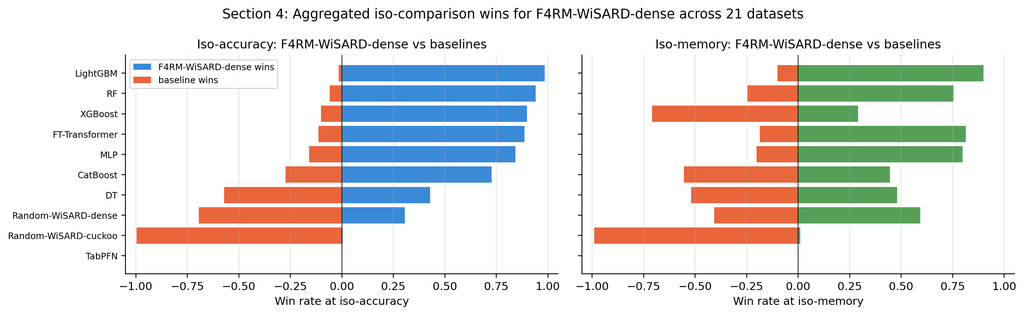

```python
# === Aggregated wins — F4RM-WiSARD-dense (basic single-mapping, dense memory) ===
display(Image(str(FIG_DIR / "section4_aggregated_wins.png"), width=1100))
```

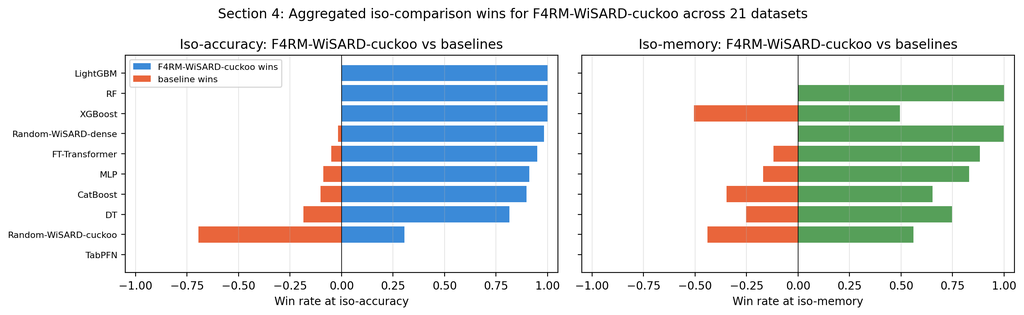

```python
# === Aggregated wins — F4RM-WiSARD-cuckoo (single-mapping, Cuckoo-filter memory) ===
display(Image(str(FIG_DIR / "section4_aggregated_wins_cuckoo.png"), width=1100))
```

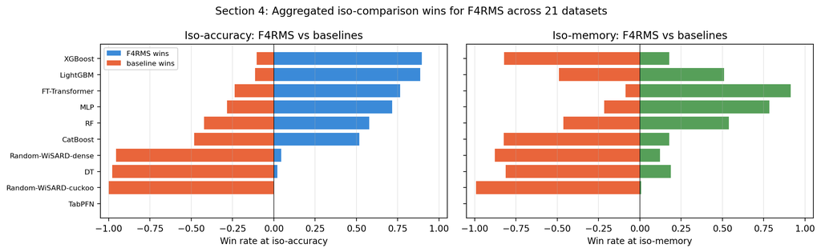

```python
# === Aggregated wins — F4RMS (K-ensemble) ===
display(Image(str(FIG_DIR / "section4_aggregated_wins_f4rms.png"), width=1100))
```

## 4.5 — Paper-drift verification

Cross-check our prior-WiSARD reproductions against the published numbers. The verification script `wisardpkg/scripts/verify_against_papers.py` reads `section4_priorwisard_points.pkl` and compares against:

- **BTHOWeN paper Table III** (6 datasets: Iris, Wine, Ecoli, Vehicle, SatImage, Letter Recognition)
- **DWN paper Table 5** (11 tabular datasets)

Per spec §8: deltas > ±5pp warrant investigation.

```python
# === Re-run paper-drift verification ===
import subprocess
out = subprocess.run(
    [sys.executable, str(PRIOR_DIR / "verify_against_papers.py")],
    capture_output=True, text=True,
)
print(out.stdout)
if out.stderr:
    print("STDERR:", out.stderr)
```

```
# Verification vs Original Papers

Cache state: {'BTHOWeN': 9036, 'ULEEN': 1674, 'DWN': 591}


## BTHOWeN — paper Table 3 vs our best-cell measurement

| Dataset | Paper acc | Our acc | Δ (pp) | Paper KiB | Our best-cell KiB | Δ KiB |
|---------|----------:|--------:|-------:|----------:|------------------:|------:|
| Iris | 0.980 | 0.960 | -2.0 | 0.281 | 0.281 | +0.000 |
| Wine | 0.983 | 0.967 | -1.6 | 0.422 | 2.438 | +2.015 |
| Ecoli | 0.875 | 0.841 | -3.4 | 0.875 | 7.000 | +6.125 |
| Vehicle | 0.762 | 0.691 ⚠️ | -7.1 | 2.250 | 4.500 | +2.250 |
| SatImage | 0.880 | 0.880 | -0.0 | 9.000 | 25.500 | +16.500 |
| Letter Recognition | 0.900 | 0.901 | +0.1 | 78.000 | 78.000 | +0.000 |

## DWN — paper Table 5 vs our best-cell measurement

| Dataset | Paper acc | Our acc | Δ (pp) | Our best-cell KiB |
|---------|----------:|--------:|-------:|------------------:|
| phoneme | 0.895 | 0.901 | +0.6 | 1968.783 |
| skin-segmentation | 1.000 | 0.986 | -1.4 | 93.750 |
| higgs-small | 0.727 | 0.639 ⚠️ | -8.8 | 5.273 |
| australian | 0.901 | 0.862 | -3.9 | 1125.000 |
| nomao | 0.966 | 0.958 | -0.8 | 93.750 |
| Segment | 0.998 | 0.975 | -2.3 | 46.781 |
| miniboone | 0.946 | 0.922 | -2.4 | 93.750 |
| christine | 0.736 | 0.696 | -4.0 | 5.273 |
| jasmine | 0.816 | 0.773 | -4.3 | 5.273 |
| sylvine | 0.952 | 0.930 | -2.2 | 46.875 |
| blood-transfusion | 0.780 | 0.771 | -0.9 | 23.438 |

## Coverage summary

- **BTHOWeN**: 9036 rows across 31 datasets, 118 unique hyperparameter cells
- **DWN**: 591 rows across 31 datasets, 14 unique hyperparameter cells
```

## 4.6 — Documented caveats and port limitations

### Methodologically clean

- All three prior-WiSARD ports (BTHOWeN, DWN, ULEEN) are **algorithmically correct** vs their respective papers (per the audit at `/tmp/prior_wisard_audit_handoff.md`). Differences are deliberate budget trade-offs or known omissions, not bugs.
- E1–E5 headline experiments use 200 paired runs per dataset with Bonferroni-corrected Wilcoxon signed-rank tests at α=0.05/21.
- Pareto frontier extraction is the standard upper-envelope on (mean memory, mean accuracy) per (system, dataset).

### Known limitations

[output not shown]

### Audit suggestions applied (from `/tmp/prior_wisard_audit_handoff.md`)

1. ⏸ BTHOWeN `srand(seed)` — deferred (reproducibility, needs C++ rebuild)
2. ✅ DWN spectral regularization
3. ✅ Memory accounting consistency (ULEEN strips H3 + input_order to match paper)
4. ✅ ULEEN Linear → Gaussian thermometer (+6pp Iris)
5. ✅ ULEEN pruning post-train step (~17–27% size reduction, ≤1% acc loss) 5b. ⏸ DWN learnable reduction — skipped per audit (FPGA-only)